# Отчёт по лабораторной работе №3 по дисциплине “Статистическое моделирование”

Шайхльбарин Денис Маратович

Выполнено: 2024-04-15

```r
library(ggplot2)
library(memisc)
library(DescTools)
library(broom)
library(caTools)
library(lmtest)
library(dplyr)
library(readxl)
```

Определение: Регрессионное уравнение (регрессионная модель) отражает зависимость между переменными: между одной зависимой (эндогенной, объясняемой) и одной или же несколькими независимыми (экзогенными, объясняющими) переменными (факторами, регрессорами). Зависимая переменная обозначается как y, а независимые объясняющие переменные как x1, x2, … , xn. Определение: Уравнение, отражающее зависимость между математическим ожиданием (условного распределения) одной переменной и соответствующими значениями другой переменной, называется регрессионным уравнением.

Наличие случайной компоненты обусловлено двумя причинами: • любая регрессионная модель является упрощением действительности (на самом деле существуют другие факторы, от которых также зависит переменная Yi); • присутствуют ошибки измерения показателей. Определение: Однофакторным линейным регрессионным уравнением называется статистическая связь между зависимой переменной y и независимым фактором (регрессором) х, представленная в виде линейной зависимости: 𝑦 = 𝑎 + 𝑏𝑥 + 𝜀 или 𝑦𝑖 = 𝑎 + 𝑏𝑥𝑖 + 𝜀𝑖

Адекватность регрессионного уравнения – соответствие его реальному моделируемому процессу, достоверность его параметров. Последовательность анализа адекватности регрессионного уравнения: 1. Оценка качества подгонки. 2. Проверка различных гипотез относительно параметров уравнения. 3. Проверка условий для получения состоятельных, несмещенных, эффективных оценок и . 4. Содержательный анализ модели и корректировка модели. 5. Прогнозирование данных по модели.

Остатки – это разность между исходными (наблюдаемыми) значениями зависимой переменной и предсказанными значениями. Исследуя остатки, мы можем оценить степень адекватности модели опытным данным. При изменении спецификации модели значение оценок остатков могут меняться. Поэтому в задачу регрессионного анализа входит не только построение самой модели, но и исследование остаточных величин.

Загрузим набор данных − diamond.

```r
dmnds <- diamonds
```

Разделим выборку на тестовую и обучающую.

```r
set.seed(56)

split <- sample.split(dmnds$price, SplitRatio = 0.75)

train <- subset(dmnds, split == TRUE)
test <- subset(dmnds, split == FALSE)
```

Построим модель линейной регрессии. В качестве зависимой переменной выступает – price, независимой – carat. Выводим полную информацию о построенной модели.

```r
model_1 <- lm(data = train, price ~ carat)

summary(model_1)
```

```
##
## Call:
## lm(formula = price ~ carat, data = train)
##
## Residuals:
##      Min       1Q   Median       3Q      Max
## -19246.6   -859.8    -23.7    566.4  12643.0
##
## Coefficients:
##             Estimate Std. Error t value Pr(>|t|)
## (Intercept) -2317.63      15.48  -149.7   <2e-16 ***
## carat        7900.65      16.11   490.5   <2e-16 ***
## ---
## Signif. codes:  0 '***' 0.001 '**' 0.01 '*' 0.05 '.' 0.1 ' ' 1
##
## Residual standard error: 1626 on 42124 degrees of freedom
## Multiple R-squared:  0.851,  Adjusted R-squared:  0.851
## F-statistic: 2.406e+05 on 1 and 42124 DF,  p-value: < 2.2e-16
```

Согласно полученным результатам уравнение регрессии имеет вид: price = -2317.63 + 7900.65 * carat

Находим коэффициенты детерминации:

```r
#коэффициент множественной корреляции
summary(lm(data = train, price ~ carat))$r.squared
```

```
## [1] 0.851
```

```r
#квадрат коэфициента скоректированной корреляции (доля дисперсии зависимой переменной price)
summary(lm(data = train, price ~ carat))$adj.r.squared
```

```
## [1] 0.8509965
```

Находим остаточную дисперсию:

```r
summary(lm(data = train, price ~ carat))$sigma^2
```

```
## [1] 2643664
```

Средняя ошибка аппроксимации

```r
A <- abs(sum((train$price - model_1$fitted.values)/train$price)) / nrow(train) * 100
str(A)
```

```
##  num 5.81
```

А < 5-7% => качество модели хорошее

Применив функцию glance(), можно также найти вышеописанные параметры:

```r
glance(model_1)
```

| r.squared | adj.r.squared | sigma | statistic | p.value | df | logLik | AIC | BIC | deviance | df.residual | nobs |
| --- | --- | --- | --- | --- | --- | --- | --- | --- | --- | --- | --- |
| 0.851 | 0.8509965 | 1625.935 | 240587.4 | 0 | 1 | -371246 | 742498.1 | 742524 | 111361717552 | 42124 | 42126 |

### Проверим условия для получения состоятельных, несмещенных, эффективных оценок

*Проверка случайности остаточной компоненты*. Построим график зависимости остатков (разность модельных и истинных значений переменной price) от спрогнозированных значений модели

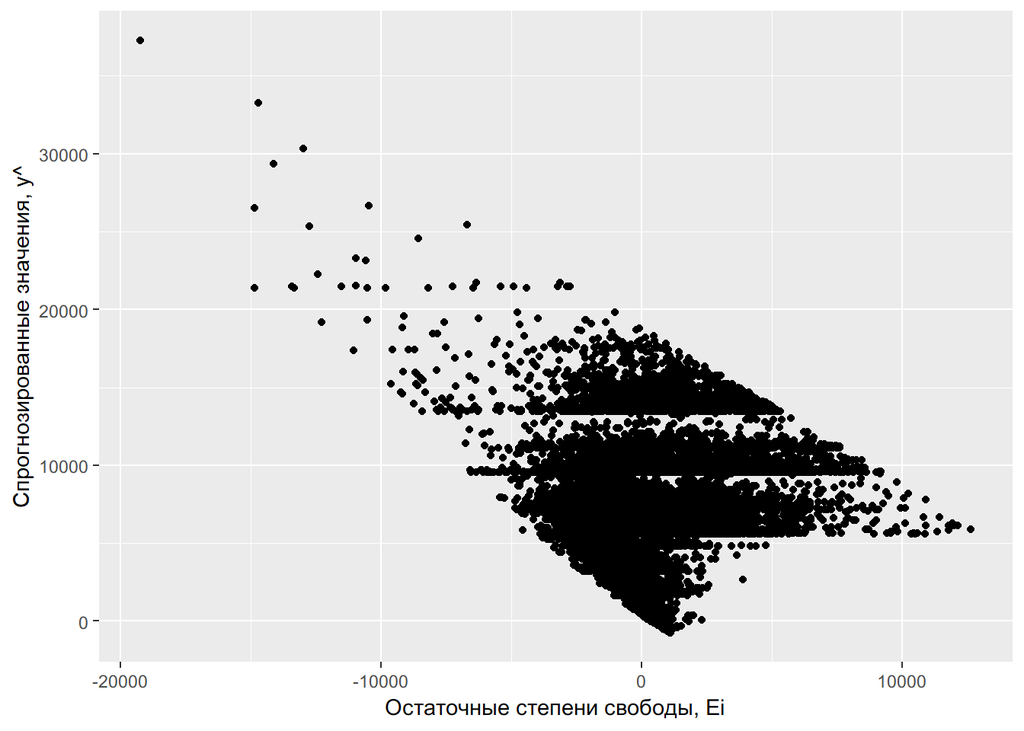

```r
qplot(y = model_1$fitted.values, x = model_1$residuals, xlab = "Остаточные степени свободы, Ei", ylab="Спрогнозированные значения, y^")
```

*Проверим условие M(Ei) = 0.*

H0: M(Ei) = 0(математическое ожидание остатков равно нулю); H1: M(Ei) != 0(математическое ожидание остатков отлично от нуля).

```r
mean(model_1$residuals)
```

```
## [1] -1.398636e-12
```

Вычисляем t расч.:

```r
a<-mean(model_1$residuals)
b<-sd(model_1$residuals, na.rm = FALSE)
n <- sqrt(42126)

tm <- a/b*n
str(tm)
```

```
##  num -1.77e-13
```

Вычисляем t табл. при p=0.95 и степени свободы N-1:

```r
df <- nrow(train)

qt(0.95, df - 1)
```

```
## [1] 1.64489
```

|t расч.| < t табл. => принимаем H0 с вероятностью p=0.95.

*Протестируем на наличие гетероскедастичности* в остатках регрессионное уравнение с помощью *теста Бройша-Погана*: H0: D(Ei) = sig^2 (отсутствие гетероскедастичности, наличие гомоскедастичности) H1: D(Ei) != sig^2 (наличие гетероскедастичности)

```r
bptest(model_1)
```

```
##
##  studentized Breusch-Pagan test
##
## data:  model_1
## BP = 6734, df = 1, p-value < 2.2e-16
```

Так как значение p-value меньше 0.05, нулевая гипотеза об отсутствие гетероскедастичности остатков отвергается.

*Наличие гетероскедастичности в остатках регрессии можно проверить с помощью теста ранговой корреляции Спирмена*.

Суть теста заключается в определении наличия связи между ростом остаточной компоненты и ростом независимого фактора, то есть определение роста дисперсии остатков. Такая зависимость проверяется на основе расчета коэффициента ранговой корреляции Спирмена ρ между остатками модели E и независимым фактором carat.

```r
cor.test (train$carat, model_1$residuals, method = "spearman")
```

```
##
##  Spearman's rank correlation rho
##
## data:  train$carat and model_1$residuals
## S = 1.5715e+13, p-value < 2.2e-16
## alternative hypothesis: true rho is not equal to 0
## sample estimates:
##        rho
## -0.2612942
```

Так как значение p-value меньше 0.05, нулевая гипотеза об отсутствие гетероскедастичности остатков отвергается.

*Проверим условие cov(Ei,Ej)=0, i!=j*

Н0: rho=0 (т.е. автокорреляция остатков отсутствует); H1: rho>0 или rho<0 (наличие положительной или отрицательной автокорреляции остатков).

```r
# тест Дарбина-Уотсона
bgtest(model_1)
```

```
##
##  Breusch-Godfrey test for serial correlation of order up to 1
##
## data:  model_1
## LM test = 9899, df = 1, p-value < 2.2e-16
```

```r
# тест Бройша- Годфри
dwtest(model_1)
```

```
##
##  Durbin-Watson test
##
## data:  model_1
## DW = 1.0539, p-value < 2.2e-16
## alternative hypothesis: true autocorrelation is greater than 0
```

Так как значение p-value меньше 0.05 => гипотеза H0 об отсутствии автокорреляции остатков отвергается.

*Проверим условие Ei ~ N(0, sig^2)*, т.е. согласуются ли остатки регрессии с нормальным законом:

H0: остатки регрессии согласуются с нормальным законом распределения H1: остатки регрессии не согласуются с нормальным законом распределения

Рассмотрим графические тесты:

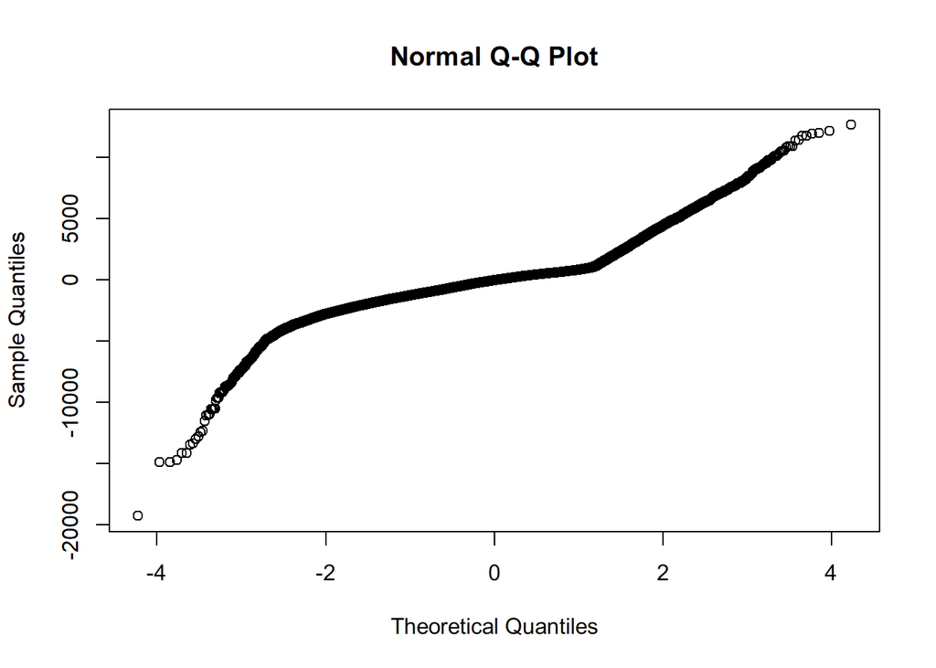

```r
qqnorm(model_1$residuals)
```

```r
library(sm);
```

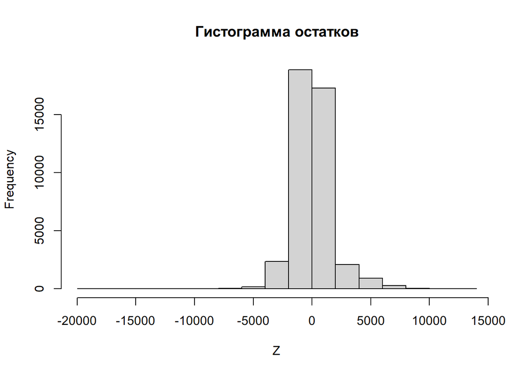

```r
Z <- model_1$residuals
hist(Z, main = "Гистограмма остатков")
```

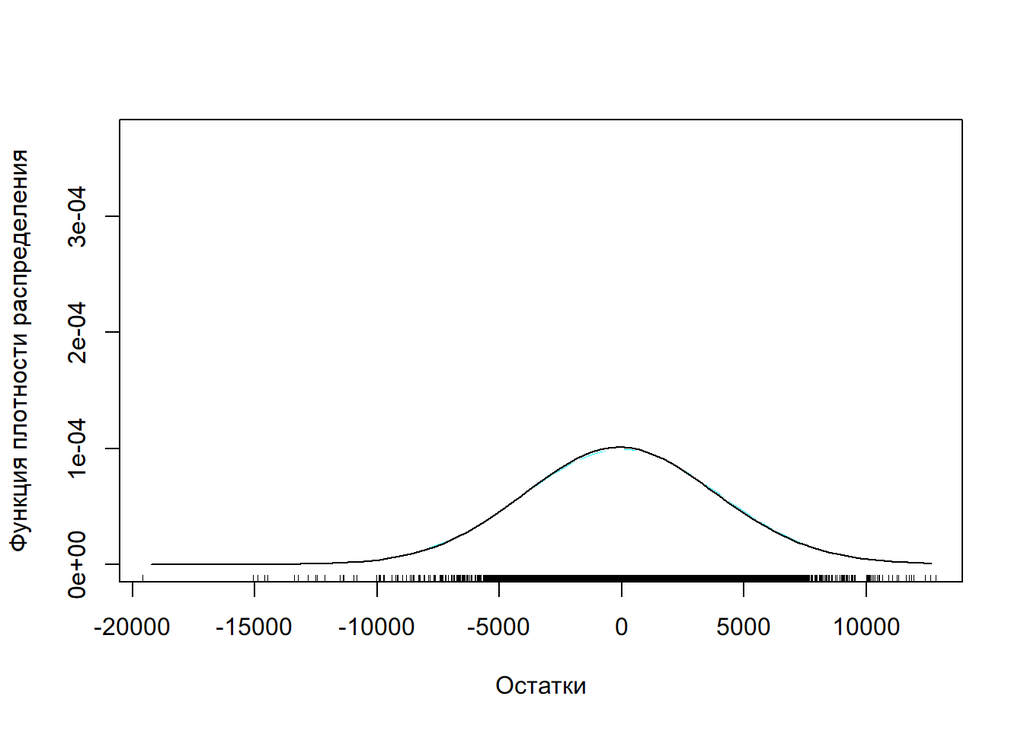

```r
sm.density(model_1$residuals, model = "Normal",xlab = "Остатки", ylab = "Функция плотности распределения", xlim=c(-19246.62,12642.95))
```

**Рассмотрим параметрические тесты:**

```r
library(nortest)

# тест Lilliefors (Kolmogorov-Smirnov)
lillie.test(model_1$residuals)
```

```
##
##  Lilliefors (Kolmogorov-Smirnov) normality test
##
## data:  model_1$residuals
## D = 0.14802, p-value < 2.2e-16
```

Так как значение p-value меньше 0.05, нулевая гипотеза о согласии распределения остатков с нормальным законом распределения отвергается.

**Рассмотрим также тест Шапиро-Уилка**. Данный тест применяется для выборки объема не менее 3 наблюдений и не более 5000. Для рассмотрения данного теста на текущей выборке выберем 4990 элементов выборки.

```r
# тест Шапиро-Уилка
sh <- model_1$residuals[1:4990]
#View(sh)
shapiro.test(sh)
```

```
##
##  Shapiro-Wilk normality test
##
## data:  sh
## W = 0.97111, p-value < 2.2e-16
```

Так как значение p-value меньше 0.05, нулевая гипотеза о согласии распределения остатков с нормальным законом распределения отвергается.

Прогнозирование значений по полученной модели на тестовой выборке:

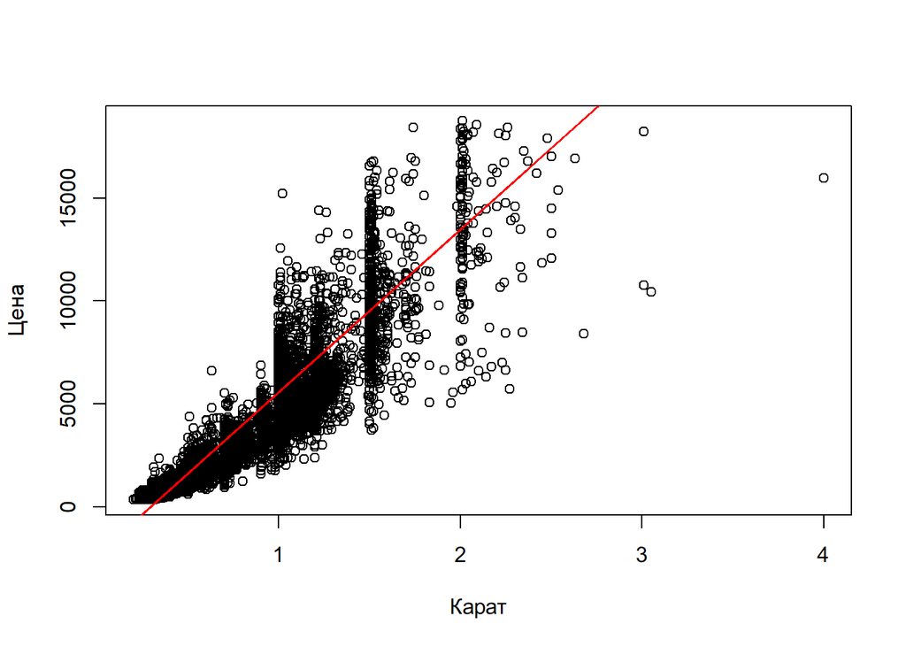

```r
plot(test$carat, test$price, xlab="Карат", ylab="Цена")
lines(test$carat, predict(model_1, test), col = 'red')
```

### Цель

Провести множественный регрессионный анализ между максимальным числом сердечных сокращений (thalach), который зависит от следующих параметров:

- age - возраст
- sex - пол
- cp - тип боли в груди
- trestbps - артериальное давление в состоянии покоя
- chol - уровень холестерола в сыворотке крови
- restecg - результаты электрокардиографии в состоянии покоя
- exang - наличие стенокардии
- oldpeak - депрессия сегмента ST сердца

Загрузим необходимые пакеты

```r
library(openxlsx)
library(caTools)
library(DescTools)
library(dplyr)
library(ggplot2)
library(glmnet)
library(tidyverse)
```

Загрузим набор данных. Источник - https://www.kaggle.com/imnikhilanand/heart-attack-prediction

```r
data <- read.csv("data.csv", sep = ",")
```

Определение: Многофакторным линейным регрессионным уравнением называется статистическая связь между зависимой переменной y и независимыми факторами (регрессорами) x1, x2, … , xk, представленная в виде линейной зависимости: Определение: Мультиколлинеарность – это наличие тесной линейной зависимости между независимыми факторами. Признаки мультиколлинеарности: 1.Оценки параметров имеют большие стандартные ошибки, малую значимость, хотя регрессия в целом является значимой (завышены значения F-статистики, R). 2. Небольшое изменение исходных данных приводит к существенному изменению оценок параметров модели. 3. Оценки параметров имеют неправильные с точки зрения теории знаки или неоправданно большие значения.

Пути устранения мультиколлинеарности: • исключение из модели одного или нескольких факторов (при этом следует учитывать значения t-статистики); • преобразование факторов, при котором уменьшается корреляция между ними (например, переход от первоначальных данных к их разностям). • Применение в качестве метода оценивания параметров регрессии метода главных компонент (МГК). • Применение альтернативных методов оценивания коэффициентов: гребневой регрессии и метода Lasso.

Для оценки качества регресионной модели разделим выборку на тестовую и обучающую

```r
set.seed(1821)

split <- sample.split(data$thalach, SplitRatio = 0.75)
train <- subset(data, split == TRUE)
test <- subset(data, split == FALSE)
```

Построим модель линейной регрессии (для оценки параметров применяется метод наименьших квадратов)

```r
m_lm <- lm(thalach ~ ., data = train)
summary(m_lm)
```

```
##
## Call:
## lm(formula = thalach ~ ., data = train)
##
## Residuals:
##      Min       1Q   Median       3Q      Max
## -107.266  -11.675    1.566   15.485   39.287
##
## Coefficients:
##               Estimate Std. Error t value Pr(>|t|)
## (Intercept)  1.903e+02  1.868e+01  10.187  < 2e-16 ***
## age         -1.303e+00  1.876e-01  -6.942 4.59e-11 ***
## sex          2.752e+00  3.551e+00   0.775  0.43925
## cp          -5.885e+00  1.848e+00  -3.184  0.00167 **
## trestbps     2.107e-01  7.722e-02   2.728  0.00691 **
## chol        -5.374e-04  1.469e-02  -0.037  0.97085
## fbs          5.076e+00  4.559e+00   1.113  0.26678
## restecg      2.000e+00  3.207e+00   0.624  0.53344
## exang       -7.412e-02  4.826e+00  -0.015  0.98776
## oldpeak     -4.586e+00  2.754e+00  -1.665  0.09733 .
## slope       -1.567e+00  2.061e+00  -0.760  0.44788
## ca           3.767e-01  1.248e+01   0.030  0.97595
## thal         3.042e-01  7.083e-01   0.429  0.66800
## num          2.273e-01  4.184e+00   0.054  0.95672
## ---
## Signif. codes:  0 '***' 0.001 '**' 0.01 '*' 0.05 '.' 0.1 ' ' 1
##
## Residual standard error: 21.01 on 213 degrees of freedom
## Multiple R-squared:  0.3584, Adjusted R-squared:  0.3192
## F-statistic: 9.152 on 13 and 213 DF,  p-value: 6.709e-15
```

Проверим линейную связь F-критерий H0: a=b 0 , (т.е. линейная связь между x и y отсутствует); H1: a>0 или b>0 (т.е. наличие линейной связи).

```r
mean_model <- mean(train$thalach)
f <- sum((m_lm$fitted.values - mean_model)^2) / summary(m_lm)$sigma^2
f
```

```
## [1] 118.9801
```

```r
f_tabl <- qf(0.95, 1, nrow(train)-2)
f_tabl
```

```
## [1] 3.88312
```

F расч | > F табл => отвергаем H0 в пользу наличия линейной связи с вероятностью 0.95.

Находим коэффициенты детерминации:

```r
#коэффициент множественной корреляции
summary(m_lm)$r.squared
```

```
## [1] 0.3583953
```

```r
#квадрат коэфициента скоректированной корреляции (доля дисперсии зависимой переменной price)
summary(m_lm)$adj.r.squared
```

```
## [1] 0.3192363
```

Значения коэффициентов детерминации довольно низки (ниже 0.5), подгонку построенной модели множественной регресии можно считать некачественной

Находим остаточную дисперсию:

```r
summary(m_lm)$sigma^2
```

```
## [1] 441.444
```

Средняя ошибка аппроксимации

```r
A <- sum(abs((train$thalach - m_lm$fitted.values)/train$thalach)) / nrow(train) * 100
str(A)
```

```
##  num 59.2
```

А > 5-7% => качество модели плохое

Построим прогноз по полученной модели на тестовой выборке

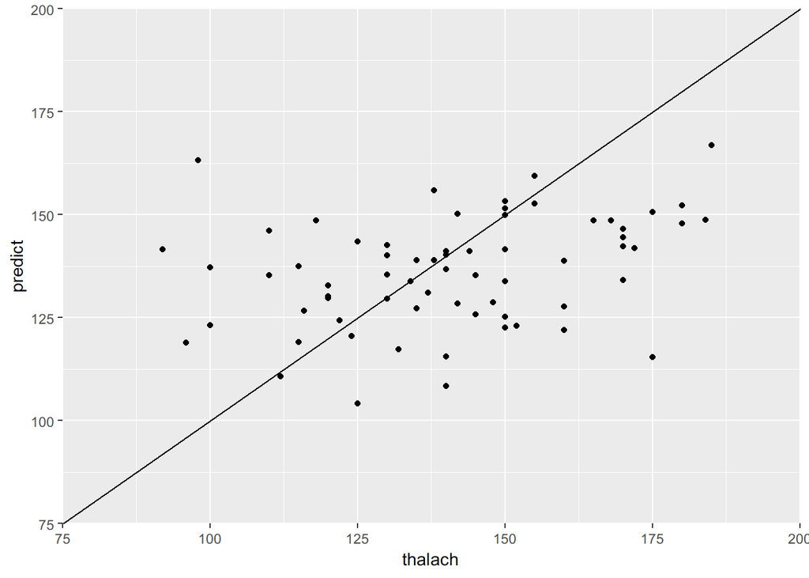

```r
test$predict <- predict(m_lm, test)

ggplot(test, aes(x = thalach, y = predict)) + geom_point() + geom_abline() + scale_x_continuous(limits = c(75, 200), expand = c(0, 0)) + scale_y_continuous(limits = c(75, 200), expand = c(0, 0))
```

Построим модель линейной регрессии, исключив незначительный параметр chol

```r
m_lm <- lm(thalach ~ age + sex + cp + trestbps + restecg + exang + oldpeak, data = train)
summary(m_lm)
```

```
##
## Call:
## lm(formula = thalach ~ age + sex + cp + trestbps + restecg +
##     exang + oldpeak, data = train)
##
## Residuals:
##      Min       1Q   Median       3Q      Max
## -107.651  -11.904    2.863   14.777   38.784
##
## Coefficients:
##              Estimate Std. Error t value Pr(>|t|)
## (Intercept) 188.55978   12.72504  14.818  < 2e-16 ***
## age          -1.27408    0.18217  -6.994  3.2e-11 ***
## sex           3.58722    3.40919   1.052 0.293859
## cp           -6.06023    1.72182  -3.520 0.000526 ***
## trestbps      0.21865    0.07609   2.873 0.004461 **
## restecg       2.09322    3.15239   0.664 0.507382
## exang        -1.38836    4.22180  -0.329 0.742579
## oldpeak      -5.94784    1.90335  -3.125 0.002019 **
## ---
## Signif. codes:  0 '***' 0.001 '**' 0.01 '*' 0.05 '.' 0.1 ' ' 1
##
## Residual standard error: 20.82 on 219 degrees of freedom
## Multiple R-squared:  0.3523, Adjusted R-squared:  0.3316
## F-statistic: 17.02 on 7 and 219 DF,  p-value: < 2.2e-16
```

Проверим линейную связь  
F-критерий  
H0: a=b 0 , (т.е. линейная связь между x и y отсутствует);  
H1: a>0 или b>0 (т.е. наличие линейной связи).

```r
mean_model <- mean(train$thalach)
f <- sum((m_lm$fitted.values - mean_model)^2) / summary(m_lm)$sigma^2
f
```

```
## [1] 119.1263
```

```r
f_tabl <- qf(0.95, 1, nrow(train)-2)
f_tabl
```

```
## [1] 3.88312
```

| F расч | > F табл => отвергаем H0 в пользу наличия линейной связи с вероятностью 0.95.  
*Находим коэффициенты детерминации*:

```r
#коэффициент множественной корреляции
summary(m_lm)$r.squared
```

```
## [1] 0.352313
```

```r
#квадрат коэфициента скоректированной корреляции (доля дисперсии зависимой переменной price)
summary(m_lm)$adj.r.squared
```

```
## [1] 0.3316107
```

Значения коэффициентов детерминации довольно низки (ниже 0.5), подгонку построенной модели множественной регресии можно считать некачественной

Находим остаточную дисперсию:

```r
summary(m_lm)$sigma^2
```

```
## [1] 433.4198
```

Средняя ошибка аппроксимации

```r
A <- sum(abs((train$thalach - m_lm$fitted.values)/train$thalach)) / nrow(train) * 100
str(A)
```

```
##  num 59.4
```

А > 5-7% => качество модели плохое

Построим прогноз по полученной модели на тестовой выборке

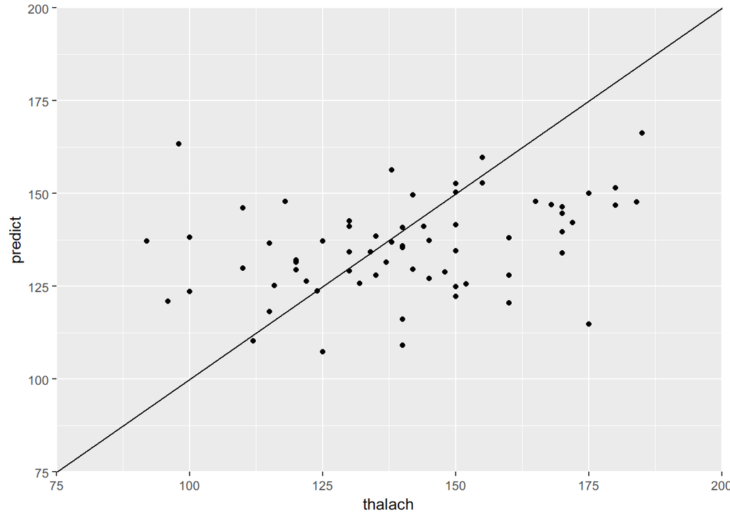

```r
test$predict <- predict(m_lm, test)

ggplot(test, aes(x = thalach, y = predict)) + geom_point() + geom_abline() + scale_x_continuous(limits = c(75, 200), expand = c(0, 0)) + scale_y_continuous(limits = c(75, 200), expand = c(0, 0))
```

Построим модель линейной регрессии, исключив следующий незначительный параметр sex

```r
m_lm <- lm(thalach ~ age + cp + trestbps + restecg + exang + oldpeak, data = train)
summary(m_lm)
```

```
##
## Call:
## lm(formula = thalach ~ age + cp + trestbps + restecg + exang +
##     oldpeak, data = train)
##
## Residuals:
##      Min       1Q   Median       3Q      Max
## -108.686  -12.587    3.297   15.384   39.326
##
## Coefficients:
##              Estimate Std. Error t value Pr(>|t|)
## (Intercept) 190.14756   12.63833  15.045  < 2e-16 ***
## age          -1.29530    0.18109  -7.153 1.25e-11 ***
## cp           -5.72528    1.69255  -3.383  0.00085 ***
## trestbps      0.22758    0.07564   3.009  0.00293 **
## restecg       1.51330    3.10459   0.487  0.62643
## exang        -1.45748    4.22232  -0.345  0.73029
## oldpeak      -5.78980    1.89787  -3.051  0.00256 **
## ---
## Signif. codes:  0 '***' 0.001 '**' 0.01 '*' 0.05 '.' 0.1 ' ' 1
##
## Residual standard error: 20.82 on 220 degrees of freedom
## Multiple R-squared:  0.349,  Adjusted R-squared:  0.3313
## F-statistic: 19.66 on 6 and 220 DF,  p-value: < 2.2e-16
```

Проверим линейную связь F-критерий H0: a=b 0 , (т.е. линейная связь между x и y отсутствует); H1: a>0 или b>0 (т.е. наличие линейной связи).

```r
mean_model <- mean(train$thalach)
f <- sum((m_lm$fitted.values - mean_model)^2) / summary(m_lm)$sigma^2
f
```

```
## [1] 117.9617
```

```r
f_tabl <- qf(0.95, 1, nrow(train)-2)
f_tabl
```

```
## [1] 3.88312
```

F расч | > F табл => отвергаем H0 в пользу наличия линейной связи с вероятностью 0.95.

Находим коэффициенты детерминации:

```r
#коэффициент множественной корреляции
summary(m_lm)$r.squared
```

```
## [1] 0.3490386
```

```r
#квадрат коэфициента скоректированной корреляции (доля дисперсии зависимой переменной price)
summary(m_lm)$adj.r.squared
```

```
## [1] 0.3312851
```

Значения коэффициентов детерминации довольно низки (ниже 0.5), подгонку построенной модели множественной регресии можно считать некачественной

Находим остаточную дисперсию:

```r
summary(m_lm)$sigma^2
```

```
## [1] 433.6309
```

Средняя ошибка аппроксимации

```r
A <- sum(abs((train$thalach - m_lm$fitted.values)/train$thalach)) / nrow(train) * 100
str(A)
```

```
##  num 59.9
```

А > 5-7% => качество модели плохое

Построим прогноз по полученной модели на тестовой выборке

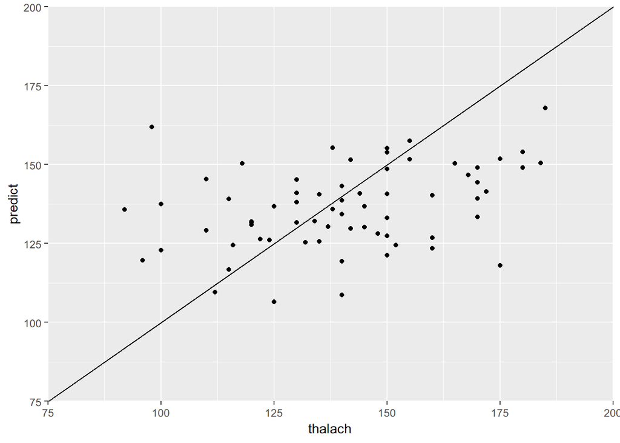

```r
test$predict <- predict(m_lm, test)

ggplot(test, aes(x = thalach, y = predict)) + geom_point() + geom_abline() + scale_x_continuous(limits = c(75, 200), expand = c(0, 0)) + scale_y_continuous(limits = c(75, 200), expand = c(0, 0))
```

Построим модель линейной регрессии, исключив следующий незначительный параметр restecg

```r
m_lm <- lm(thalach ~ age + cp + trestbps + exang + oldpeak, data = train)
summary(m_lm)
```

```
##
## Call:
## lm(formula = thalach ~ age + cp + trestbps + exang + oldpeak,
##     data = train)
##
## Residuals:
##      Min       1Q   Median       3Q      Max
## -107.688  -12.773    3.103   15.382   39.063
##
## Coefficients:
##             Estimate Std. Error t value Pr(>|t|)
## (Intercept) 190.4278    12.6035  15.109  < 2e-16 ***
## age          -1.2921     0.1807  -7.152 1.24e-11 ***
## cp           -5.7598     1.6882  -3.412 0.000767 ***
## trestbps      0.2270     0.0755   3.007 0.002948 **
## exang        -1.4629     4.2150  -0.347 0.728873
## oldpeak      -5.7170     1.8887  -3.027 0.002764 **
## ---
## Signif. codes:  0 '***' 0.001 '**' 0.01 '*' 0.05 '.' 0.1 ' ' 1
##
## Residual standard error: 20.79 on 221 degrees of freedom
## Multiple R-squared:  0.3483, Adjusted R-squared:  0.3336
## F-statistic: 23.63 on 5 and 221 DF,  p-value: < 2.2e-16
```

Проверим линейную связь F-критерий H0: a=b 0 , (т.е. линейная связь между x и y отсутствует); H1: a>0 или b>0 (т.е. наличие линейной связи).

```r
mean_model <- mean(train$thalach)
f <- sum((m_lm$fitted.values - mean_model)^2) / summary(m_lm)$sigma^2
f
```

```
## [1] 118.1316
```

```r
f_tabl <- qf(0.95, 1, nrow(train)-2)
f_tabl
```

```
## [1] 3.88312
```

F расч | > F табл => отвергаем H0 в пользу наличия линейной связи с вероятностью 0.95.

Находим коэффициенты детерминации:

```r
#коэффициент множественной корреляции
summary(m_lm)$r.squared
```

```
## [1] 0.3483356
```

```r
#квадрат коэфициента скоректированной корреляции (доля дисперсии зависимой переменной price)
summary(m_lm)$adj.r.squared
```

```
## [1] 0.3335921
```

Значения коэффициентов детерминации довольно низки (ниже 0.5), подгонку построенной модели множественной регресии можно считать некачественной

Находим остаточную дисперсию:

```r
summary(m_lm)$sigma^2
```

```
## [1] 432.135
```

Средняя ошибка аппроксимации

```r
A <- sum(abs((train$thalach - m_lm$fitted.values)/train$thalach)) / nrow(train) * 100
str(A)
```

```
##  num 59.5
```

А > 5-7% => качество модели плохое

Построим прогноз по полученной модели на тестовой выборке

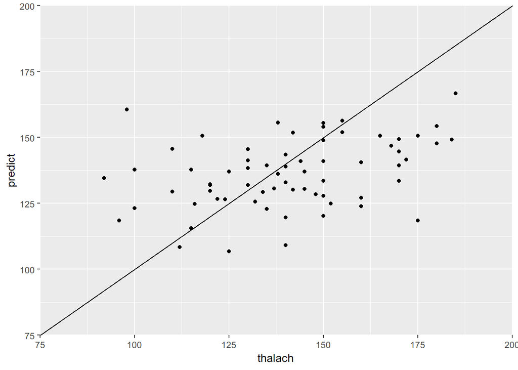

```r
test$predict <- predict(m_lm, test)

ggplot(test, aes(x = thalach, y = predict)) + geom_point() + geom_abline() + scale_x_continuous(limits = c(75, 200), expand = c(0, 0)) + scale_y_continuous(limits = c(75, 200), expand = c(0, 0))
```

```r
m_lm <- lm(thalach ~ age + cp + exang + oldpeak, data = train)
summary(m_lm)
```

```
##
## Call:
## lm(formula = thalach ~ age + cp + exang + oldpeak, data = train)
##
## Residuals:
##      Min       1Q   Median       3Q      Max
## -134.714  -13.347    1.896   14.914   41.648
##
## Coefficients:
##             Estimate Std. Error t value Pr(>|t|)
## (Intercept) 215.7897     9.5323  22.638  < 2e-16 ***
## age          -1.1896     0.1806  -6.587 3.21e-10 ***
## cp           -6.0071     1.7164  -3.500 0.000563 ***
## exang         1.0594     4.2048   0.252 0.801315
## oldpeak      -5.9498     1.9210  -3.097 0.002205 **
## ---
## Signif. codes:  0 '***' 0.001 '**' 0.01 '*' 0.05 '.' 0.1 ' ' 1
##
## Residual standard error: 21.16 on 222 degrees of freedom
## Multiple R-squared:  0.3217, Adjusted R-squared:  0.3095
## F-statistic: 26.32 on 4 and 222 DF,  p-value: < 2.2e-16
```

Проверим линейную связь F-критерий H0: a=b 0 , (т.е. линейная связь между x и y отсутствует); H1: a>0 или b>0 (т.е. наличие линейной связи).

```r
mean_model <- mean(train$thalach)
f <- sum((m_lm$fitted.values - mean_model)^2) / summary(m_lm)$sigma^2
f
```

```
## [1] 105.2797
```

```r
f_tabl <- qf(0.95, 1, nrow(train)-2)
f_tabl
```

```
## [1] 3.88312
```

F расч | > F табл => отвергаем H0 в пользу наличия линейной связи с вероятностью 0.95.

Находим коэффициенты детерминации:

```r
#коэффициент множественной корреляции
summary(m_lm)$r.squared
```

```
## [1] 0.3216811
```

```r
#квадрат коэфициента скоректированной корреляции (доля дисперсии зависимой переменной price)
summary(m_lm)$adj.r.squared
```

```
## [1] 0.3094591
```

Значения коэффициентов детерминации довольно низки (ниже 0.5), подгонку построенной модели множественной регресии можно считать некачественной

Находим остаточную дисперсию:

```r
summary(m_lm)$sigma^2
```

```
## [1] 447.7841
```

Средняя ошибка аппроксимации

```r
A <- sum(abs((train$thalach - m_lm$fitted.values)/train$thalach)) / nrow(train) * 100
str(A)
```

```
##  num 71.1
```

А > 5-7% => качество модели плохое

Построим прогноз по полученной модели на тестовой выборке

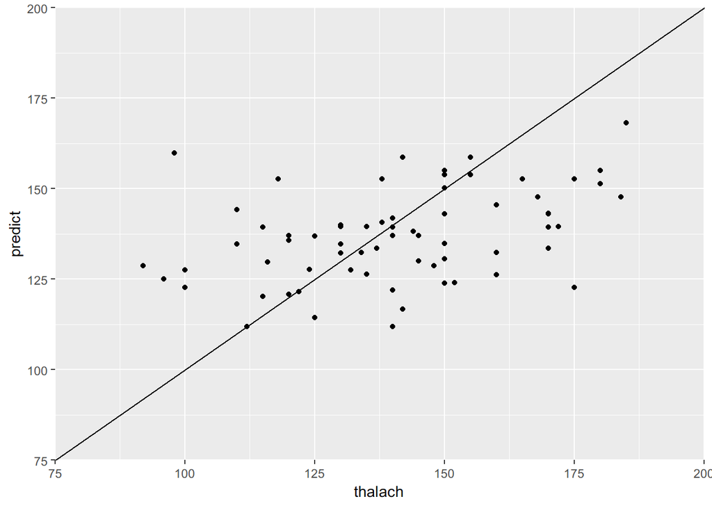

```r
test$predict <- predict(m_lm, test)

ggplot(test, aes(x = thalach, y = predict)) + geom_point() + geom_abline() + scale_x_continuous(limits = c(75, 200), expand = c(0, 0)) + scale_y_continuous(limits = c(75, 200), expand = c(0, 0))
```

```r
m_lm <- lm(thalach ~ age + cp + exang, data = train)
summary(m_lm)
```

```
##
## Call:
## lm(formula = thalach ~ age + cp + exang, data = train)
##
## Residuals:
##      Min       1Q   Median       3Q      Max
## -152.370  -12.067    2.511   15.391   39.142
##
## Coefficients:
##             Estimate Std. Error t value Pr(>|t|)
## (Intercept)  215.826      9.714  22.218  < 2e-16 ***
## age           -1.206      0.184  -6.553 3.86e-10 ***
## cp            -6.248      1.747  -3.576 0.000428 ***
## exang         -5.908      3.620  -1.632 0.104075
## ---
## Signif. codes:  0 '***' 0.001 '**' 0.01 '*' 0.05 '.' 0.1 ' ' 1
##
## Residual standard error: 21.56 on 223 degrees of freedom
## Multiple R-squared:  0.2924, Adjusted R-squared:  0.2829
## F-statistic: 30.71 on 3 and 223 DF,  p-value: < 2.2e-16
```

Проверим линейную связь F-критерий H0: a=b 0 , (т.е. линейная связь между x и y отсутствует); H1: a>0 или b>0 (т.е. наличие линейной связи).

```r
mean_model <- mean(train$thalach)
f <- sum((m_lm$fitted.values - mean_model)^2) / summary(m_lm)$sigma^2
f
```

```
## [1] 92.13651
```

```r
f_tabl <- qf(0.95, 1, nrow(train)-2)
f_tabl
```

```
## [1] 3.88312
```

F расч | > F табл => отвергаем H0 в пользу наличия линейной связи с вероятностью 0.95.

Находим коэффициенты детерминации:

```r
#коэффициент множественной корреляции
summary(m_lm)$r.squared
```

```
## [1] 0.2923701
```

```r
#квадрат коэфициента скоректированной корреляции (доля дисперсии зависимой переменной price)
summary(m_lm)$adj.r.squared
```

```
## [1] 0.2828505
```

Значения коэффициентов детерминации довольно низки (ниже 0.5), подгонку построенной модели множественной регресии можно считать некачественной

Находим остаточную дисперсию:

```r
summary(m_lm)$sigma^2
```

```
## [1] 465.0386
```

Средняя ошибка аппроксимации

```r
A <- sum(abs((train$thalach - m_lm$fitted.values)/train$thalach)) / nrow(train) * 100
str(A)
```

```
##  num 78.9
```

А > 5-7% => качество модели плохое

Построим прогноз по полученной модели на тестовой выборке

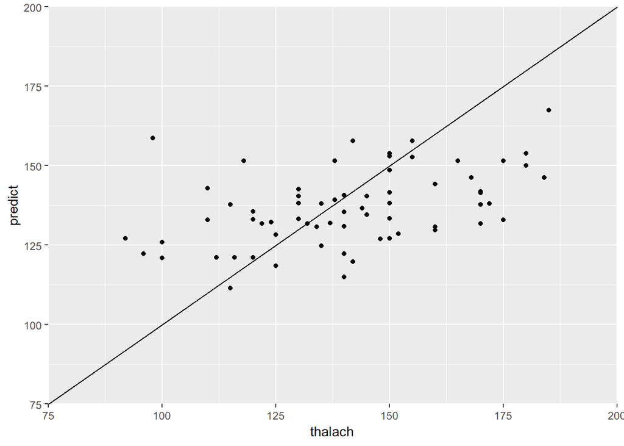

```r
test$predict <- predict(m_lm, test)

ggplot(test, aes(x = thalach, y = predict)) + geom_point() + geom_abline() + scale_x_continuous(limits = c(75, 200), expand = c(0, 0)) + scale_y_continuous(limits = c(75, 200), expand = c(0, 0))
```

### Проверим условия для получения состоятельных, несмещенных, эффективных оценок

*Проверка случайности остаточной компоненты*. Построим график зависимости остатков (разность модельных и истинных значений переменной thalach) от спрогнозированных значений модели

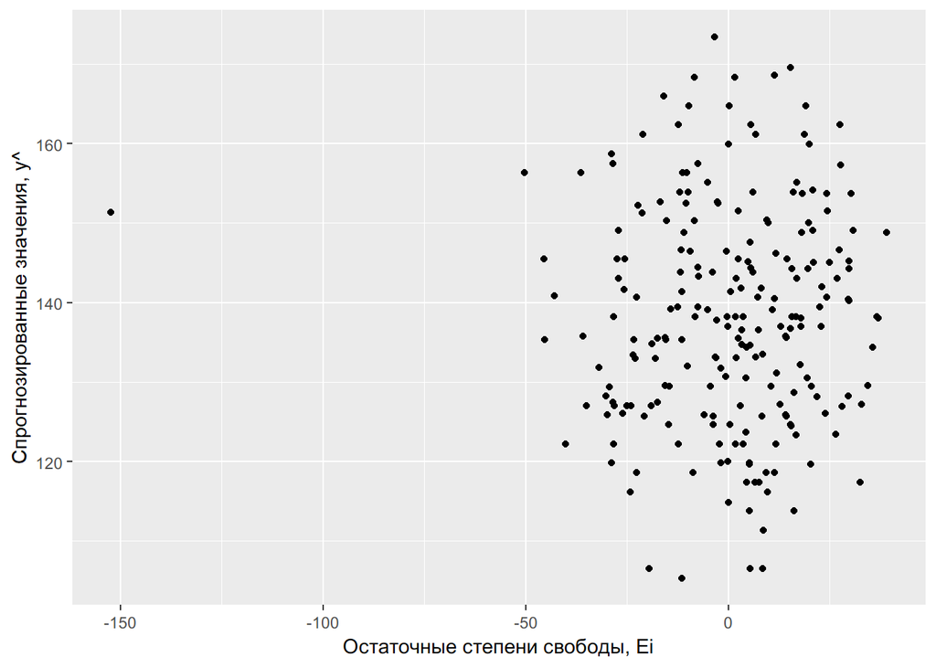

```r
qplot(y = m_lm$fitted.values, x = m_lm$residuals, xlab = "Остаточные степени свободы, Ei", ylab="Спрогнозированные значения, y^")
```

*Проверим условие M(Ei) = 0 (несмещенность)*  
H0: M(Ei) = 0(математическое ожидание остатков равно нулю);  
H1: M(Ei) != 0(математическое ожидание остатков отлично от нуля).

```r
mean(m_lm$residuals)
```

```
## [1] 1.135136e-16
```

Вычисляем t расч.:

```r
a<-mean(m_lm$residuals)
b<-sd(m_lm$residuals, na.rm = FALSE)
n <- sqrt(nrow(train)) #209 - кол-во тренировочных наблюдений

tm <- a/b*n
str(tm)
```

```
##  num 7.98e-17
```

Вычисляем t табл. при p=0.95 и степени свободы N-1:

```r
df <- nrow(train)

qt(0.95, df - 1)
```

```
## [1] 1.651624
```

|t расч.| < t табл. => принимаем H0 с вероятностью p=0.95.

*Протестируем на наличие гетероскедастичности* в остатках регрессионное уравнение с помощью *теста Бройша-Погана*: H0: D(Ei) = sig^2 (отсутствие гетероскедастичности, наличие гомоскедастичности) H1: D(Ei) != sig^2 (наличие гетероскедастичности)

```r
bptest(m_lm)
```

```
##
##  studentized Breusch-Pagan test
##
## data:  m_lm
## BP = 10.272, df = 3, p-value = 0.01639
```

*Проверим условие cov(Ei,Ej)=0, i!=j*  
Н0: rho=0 (т.е. автокорреляция остатков отсутствует);  
H1: rho>0 или rho<0 (наличие положительной или отрицательной автокорреляции остатков).

```r
# тест Дарбина-Уотсона
bgtest(m_lm)
```

```
##
##  Breusch-Godfrey test for serial correlation of order up to 1
##
## data:  m_lm
## LM test = 0.62392, df = 1, p-value = 0.4296
```

```r
# тест Бройша- Годфри
dwtest(m_lm)
```

```
##
##  Durbin-Watson test
##
## data:  m_lm
## DW = 2.101, p-value = 0.7504
## alternative hypothesis: true autocorrelation is greater than 0
```

Так как значение p-value больше 0.05 => гипотеза H0 об отсутствии автокорреляции остатков принимается

*Проверим условие Ei ~ N(0, sig^2)*, т.е. согласуются ли остатки регрессии с нормальным законом:  
H0: остатки регрессии согласуются с нормальным законом распределения;  
H1: остатки регрессии не согласуются с нормальным законом распределения

Рассмотрим графические тесты:

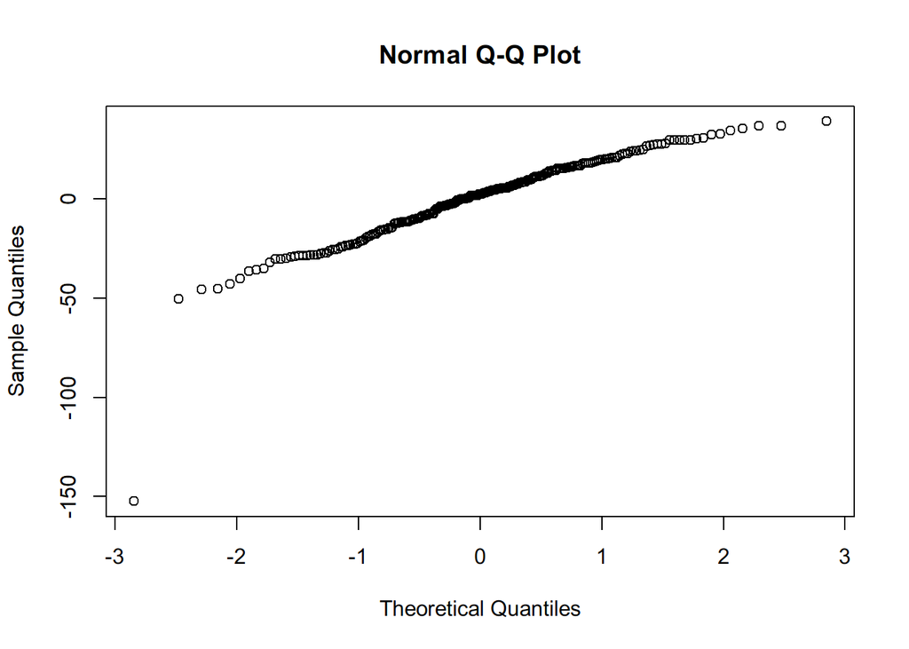

```r
qqnorm(m_lm$residuals)
```

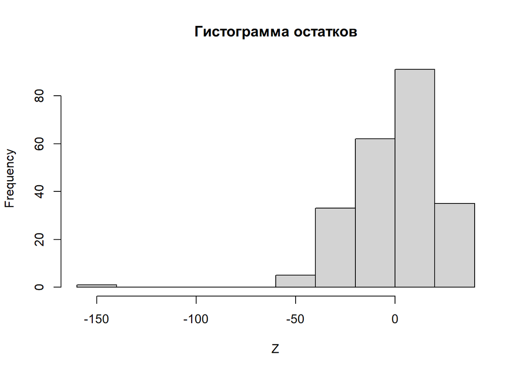

```r
library(sm);
Z <- m_lm$residuals
hist(Z, main = "Гистограмма остатков")
```

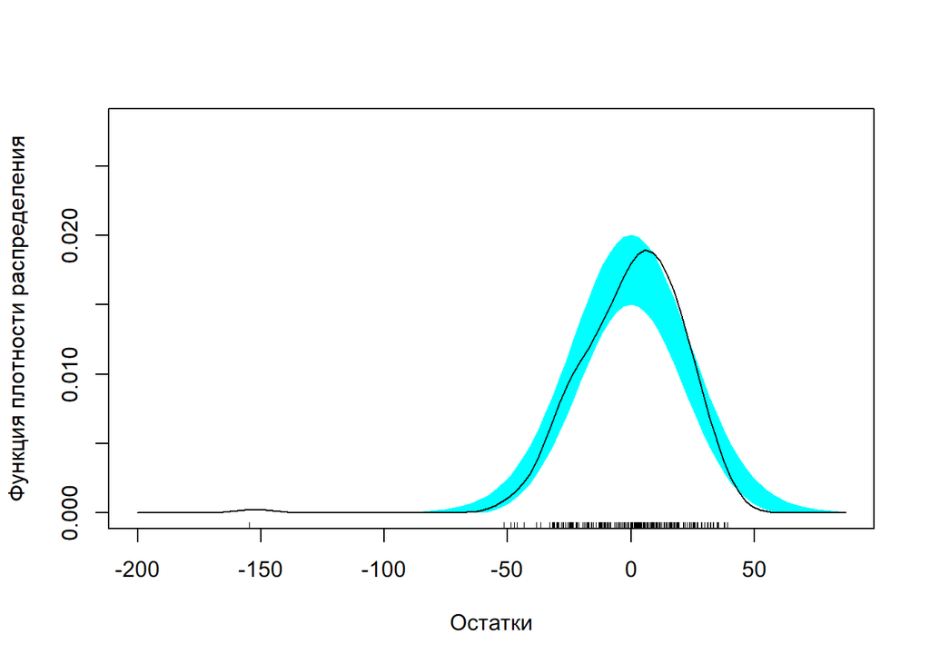

```r
sm.density(m_lm$residuals, model = "Normal",xlab = "Остатки", ylab = "Функция плотности распределения")
```

Рассмотрим параметрические тесты:

```r
library(nortest)

# тест Lilliefors (Kolmogorov-Smirnov)
lillie.test(m_lm$residuals)
```

```
##
##  Lilliefors (Kolmogorov-Smirnov) normality test
##
## data:  m_lm$residuals
## D = 0.064565, p-value = 0.02267
```

*Анализ мультиколлинеарности*:

Мультиколлинеарность - яление, при котором одна из входных переменных статистической модели линейно зависит от других входных переменных (присутствует сильная корреляция).

Вычислим значения коэффициентов увеличения дисперсии VIF

```r
VIF(m_lm)
```

```
##      age       cp    exang
## 1.071607 1.389015 1.452047
```

Подготовим данные, учитывая исключенные факторы

```r
train_y <- train$thalach
train_x <- data.frame(age=train$age, cp=train$cp, exang=train$exang) %>% data.matrix()
test_x <- data.frame(age=test$age, cp=test$cp, exang=test$exang)  %>% data.matrix()
```

Применим методы Ридж и Lasso для оценки параметров регрессии с целью сравнения моделей. Методы регрессии Ридж и LASSO осуществляют регуляризацию параметров и позволяют преодолеть некоторые недостатки метода наименьших квадратов.

Гребнева регрессия (ридж-оценки). Гребневая регрессия полностью не устраняет проблему мультиколлинеарности, кроме того приводит к незначительно смещенным оценкам коэффициентам регрессии, но повышает надежность модели в целом. Как правило, мультиколлинарность может давать «неправильные» с точки зрения теории знаки в регрессии, гребневая регрессия призвана устранить этот недостаток.

Оценим параметры с помощью метода Ридж. Для Ридж-регрессии (гребневой) различные значения λ будут генерировать различные наборы оценок параметров.

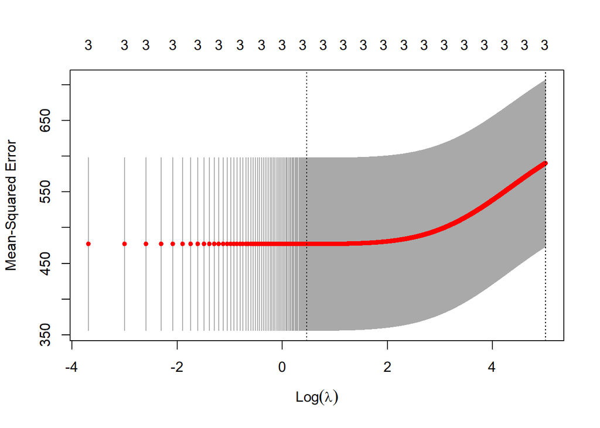

```r
lambdas <- seq(0, 150, by = 0.025)

set.seed(1877)
cv_ridge <- cv.glmnet(train_x, train_y, alpha = 0, lambda = lambdas)
plot(cv_ridge)
```

На графике показана зависимость MSE (средней квадратической ошибки) предсказания от λ. Одна из вертикальных линий пунктирных линий показывает положение минимума MSE. Вторая пунктирная линия обозначает точку, выбранную по «правилу одной стандартной ошибки».

Определим подходящие значения λ исходя из минимума ошибок

```r
cv_ridge$lambda.min
```

```
## [1] 1.6
```

Построим модель линейной регрессии с помощью метода Ридж

```r
set.seed(1877)
m_ridge <- glmnet(train_x, train_y, alpha = 0, lambda = cv_ridge$lambda.min)
coef(m_ridge)
```

```
## 4 x 1 sparse Matrix of class "dgCMatrix"
##                     s0
## (Intercept) 211.557038
## age          -1.136159
## cp           -5.890562
## exang        -6.203569
```

Построим прогноз для полученной модели на тестовой выборке

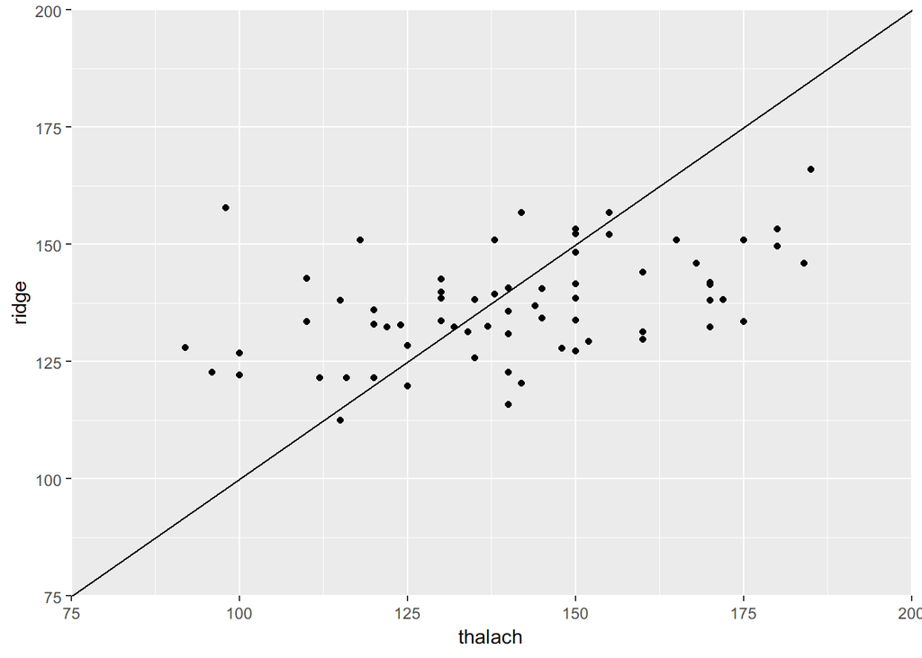

```r
test$ridge <- predict(m_ridge, s = cv_ridge$lambda.min, newx = test_x)

ggplot(test, aes(x = thalach, y = ridge)) + geom_point() + geom_abline() + scale_x_continuous(limits = c(75, 200), expand = c(0, 0)) + scale_y_continuous(limits = c(75, 200), expand = c(0, 0))
```

Оценим параметры модели с помощью метода LASSO (Least Absolute Shrinkage and Selection Operator)

Метод LASSO Метод Lasso не сильно отличается от метода гребневой регрессии, суть в том, что на параметр регуляризации накладывается ряд ограничений. Метод регрессии «Лассо» (LASSO, Least Absolute Shrinkage and Selection Operator) заключается во введении дополнительного слагаемого регуляризации в функционал оптимизации модели, что часто позволяет получать более устойчивое решение. В методе Lasso параметр регуляризации вводится в функцию потерь.

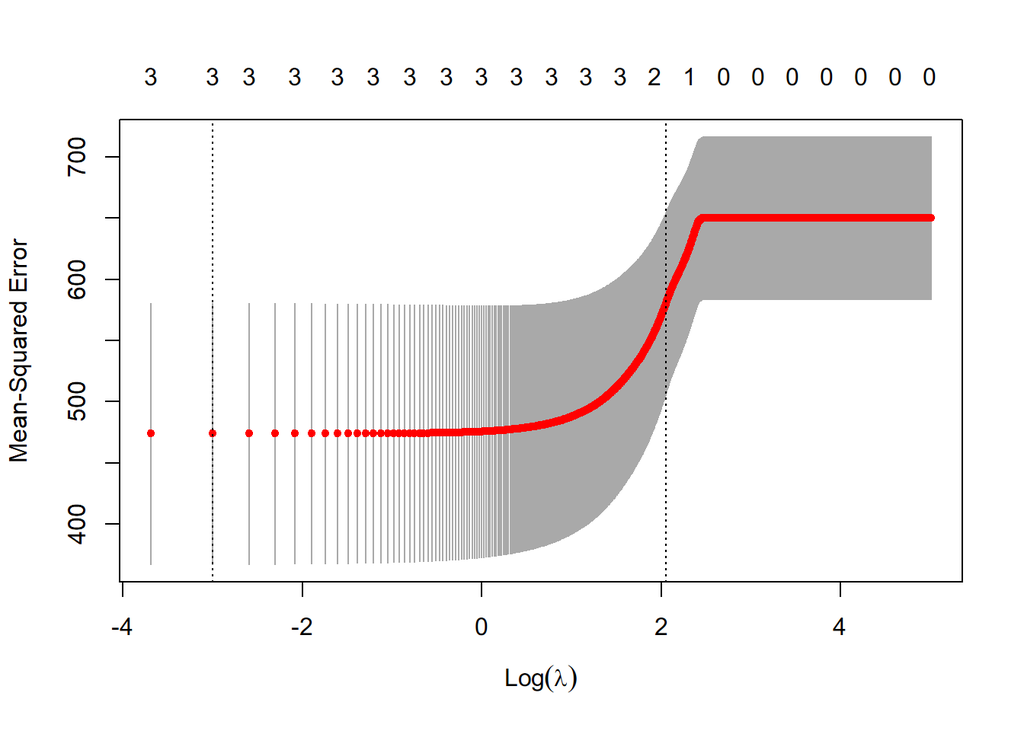

```r
set.seed(1886)
cv_lasso <- cv.glmnet(train_x, train_y, alpha = 1, lambda = lambdas)
plot(cv_lasso)
```

Определим подходящие значения λ исходя из минимума ошибок

```r
cv_lasso$lambda.min
```

```
## [1] 0.05
```

Построим модель линейной регрессии с помощью метода Lasso.

```r
set.seed(1886)
m_lasso <- glmnet(train_x, train_y, alpha = 1, lambda = cv_lasso$lambda.min)
coef(m_lasso)
```

```
## 4 x 1 sparse Matrix of class "dgCMatrix"
##                     s0
## (Intercept) 215.482214
## age          -1.200702
## cp           -6.215983
## exang        -5.859509
```

Построим прогноз по полученной модели на тестовой выборке

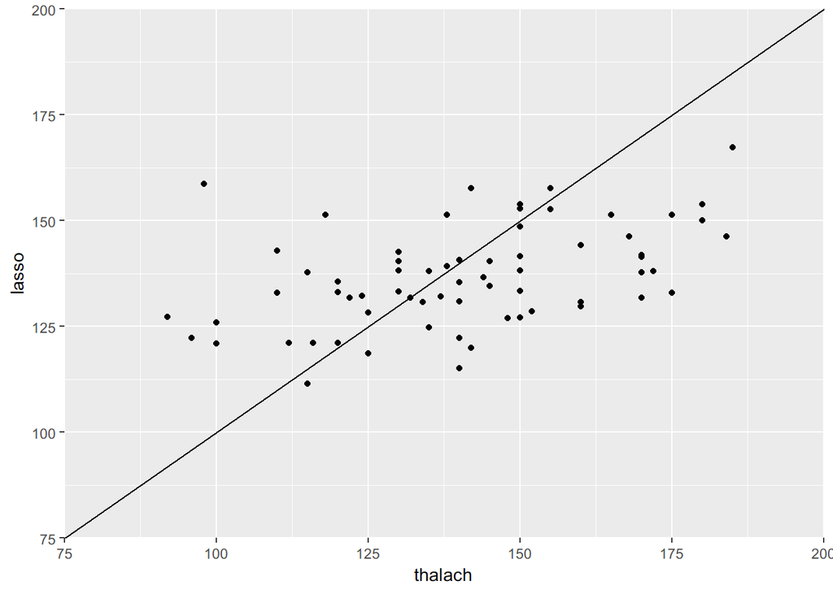

```r
test$lasso <- predict(m_lasso, s = cv_lasso$lambda.min, newx = test_x)
ggplot(test, aes(x = thalach, y = lasso)) + geom_point() + geom_abline() + scale_x_continuous(limits = c(75, 200), expand = c(0, 0)) + scale_y_continuous(limits = c(75, 200), expand = c(0, 0))
```

Рассчитаем следующие метрики для моделей, полученных с использованием различных методов для оценки параметров: - MAPE - средняя абсолютная ошибка в процентах, - RMSE - квадратный корень из среднеквадратичной ошибки, - MAE - средняя абсолютная ошибка.

```r
predict <- data.frame(
  MAPE = MAPE(x = test$predict, ref = test$thalach)*100,
  RMSE = RMSE(x = test$predict, ref = test$thalach),
  MAE = MAE(x = test$predict, ref = test$thalach)
)

ridge <- data.frame(
  MAPE = MAPE(x = test$ridge, ref = test$thalach)*100,
  RMSE = RMSE(x = test$ridge, ref = test$thalach),
  MAE = MAE(x = test$ridge, ref = test$thalach)
)

lasso <- data.frame(
  MAPE = MAPE(x = test$lasso, ref = test$thalach)*100,
  RMSE = RMSE(x = test$lasso, ref = test$thalach),
  MAE = MAE(x = test$lasso, ref = test$thalach)
)
```

```r
data.frame(rbind.data.frame(predict, ridge, lasso), row.names = c("Метод наим. квадратов", "Ridge", "LASSO"))
```

|  | MAPE | RMSE | MAE |
| --- | --- | --- | --- |
| Метод наим. квадратов | 12.11598 | 20.79941 | 16.57625 |
| Ridge | 12.08524 | 20.74773 | 16.52004 |
| LASSO | 12.11352 | 20.79495 | 16.57278 |

Метод Ridge показывает меньшую ошибку. В нашем случае прогноз методом LASSO и наименьших квадратов показывают практически одинаковые результаты, а VIF-критерий < 10. Мультиколлинеарность отсуствует.